# PB3

Le modèle de la forêt d’isolement (Isolation Forest) est un algorithme d’apprentissage non supervisé utilisé principalement pour la détection d’anomalies.

Principe :

Au lieu de modéliser la distribution des données normales, l’Isolation Forest isole directement les observations. Elle construit de nombreux arbres binaires aléatoires où, à chaque nœud, une caractéristique et une valeur de coupure sont choisies au hasard. Les points anormaux, étant rares et différents, sont plus faciles à isoler : ils nécessitent moins de divisions pour être séparés du reste des données.

Idée clé :

Moins une observation nécessite de divisions pour être isolée, ➜ plus elle est susceptible d’être une anomalie.

Avantages :

Très efficace sur de grands volumes de données. Ne nécessite pas d’étiquettes (non supervisé). Gère bien les données de grande dimension.

```r
data<- read.csv("KPIs for telecommunication.csv", sep = ";")
```

```r
summary(data)
```

```
##       KPI1             KPI2             KPI3                KPI4
##  Min.   :  0.00   Min.   :  0.00   Min.   :0.000e+00   Min.   : 80.00
##  1st Qu.: 92.31   1st Qu.:  0.00   1st Qu.:9.090e+02   1st Qu.:100.00
##  Median :100.00   Median :  1.50   Median :3.013e+05   Median :100.00
##  Mean   : 75.91   Mean   : 14.97   Mean   :3.427e+07   Mean   : 99.96
##  3rd Qu.:100.00   3rd Qu.: 17.01   3rd Qu.:1.796e+07   3rd Qu.:100.00
##  Max.   :100.00   Max.   :472.98   Max.   :1.437e+09   Max.   :100.00
##                                                        NA's   :501
##       KPI5                KPI6              KPI7              KPI8
##  Min.   :        0   Min.   : 0.0000   Min.   :      0   Min.   :-1.11100
##  1st Qu.:      858   1st Qu.: 0.0000   1st Qu.:      0   1st Qu.: 0.00000
##  Median :   174517   Median : 0.0000   Median :    880   Median : 0.00000
##  Mean   :  7614980   Mean   : 0.4346   Mean   :  37157   Mean   : 0.03844
##  3rd Qu.:  5163472   3rd Qu.: 0.0000   3rd Qu.:  25400   3rd Qu.: 0.00000
##  Max.   :219999750   Max.   :50.0000   Max.   :1114640   Max.   :20.00000
##                      NA's   :282
##       KPI9            KPI10
##  Min.   : 87.50   Min.   :0.000e+00
##  1st Qu.:100.00   1st Qu.:9.984e+03
##  Median :100.00   Median :6.886e+05
##  Mean   : 99.93   Mean   :4.219e+07
##  3rd Qu.:100.00   3rd Qu.:2.703e+07
##  Max.   :104.76   Max.   :1.576e+09
##  NA's   :382
```

```r
missing_count <- colSums(is.na(data))

cat("\nPourcentage de valeurs manquantes:\n")
```

```
##
## Pourcentage de valeurs manquantes:
```

```r
print(round(missing_count / nrow(data) * 100, 2))
```

```
##  KPI1  KPI2  KPI3  KPI4  KPI5  KPI6  KPI7  KPI8  KPI9 KPI10
##  0.00  0.00  0.00 36.70  0.00 20.66  0.00  0.00 27.99  0.00
```

## Gestion des valeurs manquantes (KPI4, KPI6, KPI9)

Pour traiter ces donnees manquantes, nous allons dans un premier temps envisager plusieurs approches :

- Remplacement par la **moyenne** ou la **mediane**.
- Utilisation de la methode des **k plus proches voisins (kNN)**, apres avoir examine la matrice de correlation afin de verifier si les autres KPI influencent les KPI4, KPI6 et KPI9 (qui presentent respectivement 36.70 %, 20.66 % et 27.99 % de valeurs manquantes).
- Suppression eventuelle des variables, si aucune methode d’imputation n’est pertinente.

#1. KNN

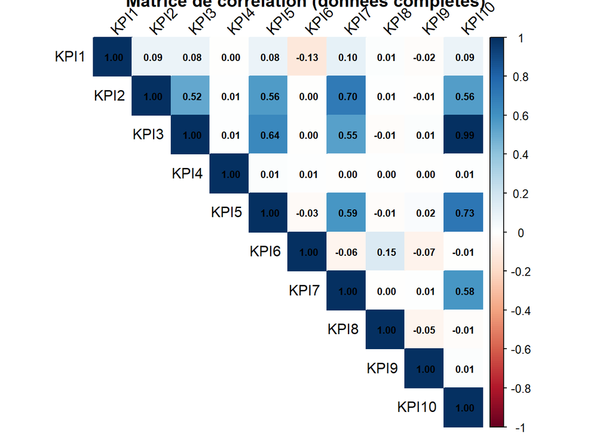

```r
# Matrice de corrélation sur données complètes

data_complete <- na.omit(data)

# Calcul et visualisation de la corrélation
cor_matrix <- cor(data_complete)


# Visualisation
library(corrplot)
corrplot(cor_matrix, method = "color", type = "upper",
         addCoef.col = "black", number.cex = 0.7,
         tl.col = "black", tl.srt = 45,
         title = "Matrice de corrélation (données complètes)")
```

```r
# Corrélations avec les KPI à imputer
cat("\nCorrélations avec KPI4:\n")
```

```
##
## Corrélations avec KPI4:
```

```r
print(sort(cor_matrix[, "KPI4"], decreasing = TRUE)[c(1,2,3)])
```

```
##       KPI4       KPI5       KPI6
## 1.00000000 0.01329184 0.00916166
```

```r
cat("\nCorrélations avec KPI6:\n")
```

```
##
## Corrélations avec KPI6:
```

```r
print(sort(cor_matrix[, "KPI6"], decreasing = TRUE)[c(1,2,3)])
```

```
##       KPI6       KPI8       KPI4
## 1.00000000 0.15164778 0.00916166
```

```r
cat("\nCorrélations avec KPI9:\n")
```

```
##
## Corrélations avec KPI9:
```

```r
print(sort(cor_matrix[, "KPI9"], decreasing = TRUE)[c(1,2,3)])
```

```
##       KPI9       KPI5      KPI10
## 1.00000000 0.02014820 0.01339141
```

Apres analyse, aucune des variables (KPI4, KPI6, KPI9) n’est correlee de maniere significative avec les autres. Dans ce cas, l’utilisation du kNN ou d’un modele de regression n’est pas adaptee, car ces methodes reposent justement sur des relations entre variables.

En observant les statistiques descriptives, on constate que la mediane est bien plus representative pour ces indicateurs :

- **KPI4** : min = 80, 1er quartile = 100, max = 100 → la valeur 80 est un outlier ; il est logique d’imputer les valeurs manquantes par 100.
- Le meme raisonnement s’applique a **KPI6** et **KPI9**.

**En conclusion**, avant d’utiliser des methodes plus complexes (comme le kNN, plus couteux en temps de calcul), il est preferable d’analyser les statistiques descriptives. Celles-ci permettent souvent d’opter pour une approche simple, robuste et coherente.

Ainsi, nous choisissons de **ne supprimer aucune observation** et de **remplacer toutes les valeurs manquantes par la mediane de la colonne concernee**.

```r
library(dplyr)
data_final <- data %>%
  mutate(across(everything(), ~ifelse(is.na(.x), median(.x, na.rm = TRUE), .x)))
```

```r
# Détection des outliers
detect_outliers <- function(x) {
  Q1 <- quantile(x, 0.25, na.rm = TRUE)
  Q3 <- quantile(x, 0.75, na.rm = TRUE)
  IQR <- Q3 - Q1
  lower <- Q1 - 1.5 * IQR
  upper <- Q3 + 1.5 * IQR
  which(x < lower | x > upper)
}

outliers_list <- lapply(data, detect_outliers)
outliers_count <- sapply(outliers_list, length)

cat("\n### Nombre d'outliers par variable\n")
```

```
##
## ### Nombre d'outliers par variable
```

```r
print(outliers_count)
```

```
##  KPI1  KPI2  KPI3  KPI4  KPI5  KPI6  KPI7  KPI8  KPI9 KPI10
##   331   136   240     6   231   189   222    41    86   231
```

```r
lignes_outliers <- unique(unlist(outliers_list))

cat("\n**Nombre total de lignes avec au moins un outlier:**", length(lignes_outliers), "\n")
```

```
##
## **Nombre total de lignes avec au moins un outlier:** 747
```

```r
# Stocker les numéros de ligne avec >= 3 outliers
outliers_detected <- c()

for(ligne in lignes_outliers) {
  features_pb <- names(outliers_list)[sapply(outliers_list, function(x) ligne %in% x)]

  # Afficher et stocker uniquement si >= 3 outliers
  if(length(features_pb) >= 3) {
    outliers_detected <- c(outliers_detected, ligne)
    valeurs <- sapply(features_pb, function(f) data[ligne, f])
  }
}

cat("\n**Total lignes avec >= 3 outliers:**", length(outliers_detected), "\n")
```

```
##
## **Total lignes avec >= 3 outliers:** 234
```

```r
cat("\nSummary des outliers par feature:\n")
```

```
##
## Summary des outliers par feature:
```

```r
for(feature in names(outliers_list)) {
  if(length(outliers_list[[feature]]) > 0) {
    cat("\n", feature, ":\n", sep="")
    valeurs_outliers <- data[outliers_list[[feature]], feature]
    print(summary(valeurs_outliers))
  }
}
```

```
##
## KPI1:
##    Min. 1st Qu.  Median    Mean 3rd Qu.    Max.
##   0.000   0.000   0.000   1.773   0.000  80.000
##
## KPI2:
##    Min. 1st Qu.  Median    Mean 3rd Qu.    Max.
##   42.99   53.37   64.26   89.28   92.38  472.98
##
## KPI3:
##      Min.   1st Qu.    Median      Mean   3rd Qu.      Max.
## 4.497e+07 7.451e+07 1.148e+08 1.752e+08 2.054e+08 1.437e+09
##
## KPI4:
##    Min. 1st Qu.  Median    Mean 3rd Qu.    Max.
##   80.00   96.85   97.18   94.93   98.41   99.67
##
## KPI5:
##      Min.   1st Qu.    Median      Mean   3rd Qu.      Max.
##  12925096  19626565  28475224  38791341  45751842 219999750
##
## KPI6:
##    Min. 1st Qu.  Median    Mean 3rd Qu.    Max.
##   0.030   0.179   0.503   2.490   1.449  50.000
##
## KPI7:
##    Min. 1st Qu.  Median    Mean 3rd Qu.    Max.
##   63960  101530  157500  193724  249153 1114640
##
## KPI8:
##    Min. 1st Qu.  Median    Mean 3rd Qu.    Max.
##  -1.111   0.091   0.216   1.280   0.588  20.000
##
## KPI9:
##    Min. 1st Qu.  Median    Mean 3rd Qu.    Max.
##   87.50   99.60   99.82   99.22   99.90  104.76
##
## KPI10:
##      Min.   1st Qu.    Median      Mean   3rd Qu.      Max.
## 6.758e+07 1.053e+08 1.576e+08 2.159e+08 2.585e+08 1.576e+09
```

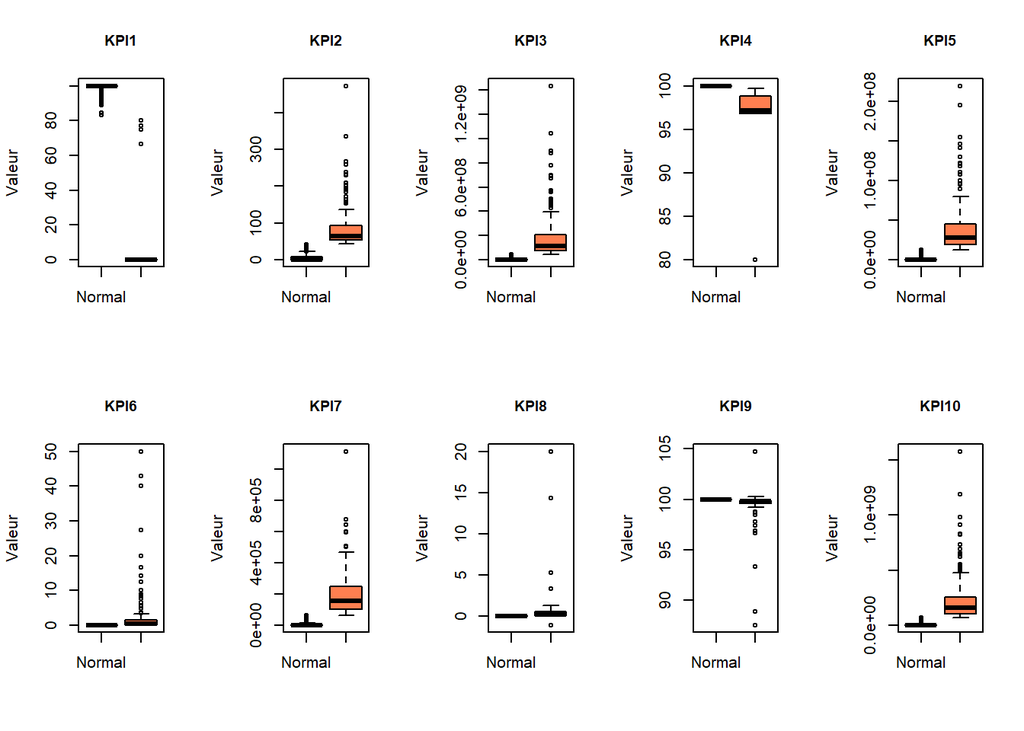

```r
# Préparer les données pour le plot
features_with_outliers <- names(outliers_list)[sapply(outliers_list, function(x) length(x) > 0)]

par(mfrow = c(2, ceiling(length(features_with_outliers)/2)))

for(feature in features_with_outliers) {
  valeurs_normales <- data[-outliers_list[[feature]], feature]
  valeurs_outliers <- data[outliers_list[[feature]], feature]

  boxplot(list(Normal = valeurs_normales, Outliers = valeurs_outliers),
          main = feature,
          col = c("lightblue", "coral"),
          ylab = "Valeur",
          cex.main = 0.9)
}
```

```r
par(mfrow = c(1, 1))
```

## Analyse critique de la détection d’outliers par la méthode IQR

En comparant les statistiques des outliers détectés avec la méthode IQR (seuil 1.5 × IQR) et celles des valeurs normales, on observe plusieurs problèmes majeurs :

- **KPI9** : Les outliers détectés ont des statistiques globales très proches des non-outliers, suggérant une sur-détection.
- **KPI8 et KPI6** : Même constat, la méthode IQR capture trop de valeurs qui ne sont pas réellement aberrantes.

Cette méthode statistique classique s’avère **inadaptée à notre jeu de données**. Cependant, elle nous fournit une baseline de **234 lignes potentiellement aberrantes** qui servira de référence pour évaluer les modèles Isolation Forest.

### Cas particulier : KPI1 = 0

Un problème majeur émerge : environ **330 lignes sur 1365 (25%)** sont marquées comme outliers uniquement parce que **KPI1 = 0**.

> **Question critique** : Doit-on considérer toutes ces lignes comme des anomalies ? **Non, je ne pense pas**.

Une valeur nulle pour KPI1 peut être légitime selon le contexte métier (absence d’activité, période de maintenance, etc.). Il en va de même pour KPI9. Étant donné qu’on a pas le contexte, on ne peut pas conclure.

### Critère de sélection du meilleur modèle

Cette méthode pourra quand même nous aider pour juger les modèles Isolation Forest. D’après notre interprétation, le modèle devra :

1. **Ne pas classifier systématiquement comme anomalie** les lignes où KPI1 = 0. Les observations avec KPI1 = 0 ne font pas ressortir en général d’autres potentielles outliers pour les autres feature en partant de ce principe. On va classer les modèles de sorte que le meilleur soit celui qui : **Maximise le F1-score** en identifiant les lignes avec réellement 3+ features aberrantes simultanément.

Le meilleur modèle sera donc celui qui fait preuve de **discernement contextuel** et ne se laisse pas piéger par des valeurs nulles fréquentes mais potentiellement normales.

Dans la prochaine partie on va tester l’influence des hyperparamètres sur 4 différents modèles

```r
library(isotree)
```

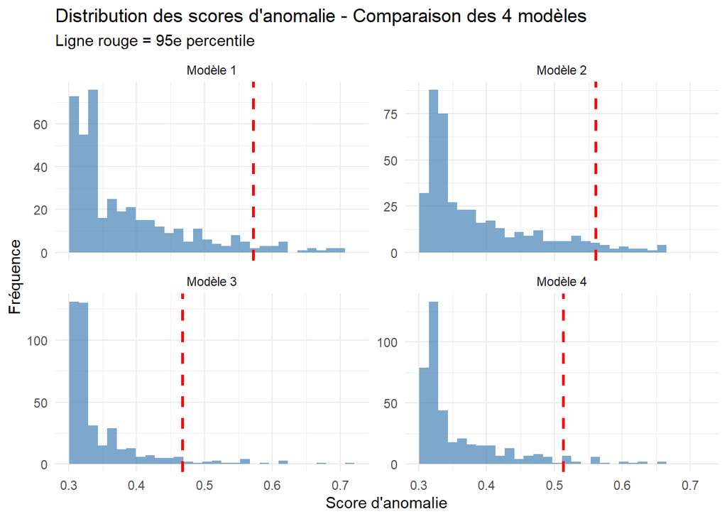

```r
library(ggplot2)
library(rsample)
library(dplyr)

# Division train/test
set.seed(123)
splitter <- data_final %>%
  rsample::initial_split(prop = 0.7)
train <- rsample::training(splitter)
test  <- rsample::testing(splitter)


# Définition de 4 modèles différents
configs <- data.frame(
  model = c("Modèle 1", "Modèle 2", "Modèle 3", "Modèle 4"),
  ntrees = c(100, 500, 500, 250),
  sample_size = c(100, 100, 512, 256),
  ndim = c(1, 1, 3, 2)
)

# Stockage des résultats
all_scores <- list()
comparison_results <- data.frame()

for(i in 1:nrow(configs)) {
  # Entraînement du modèle
  model <- isolation.forest(train,
                           ntrees = configs$ntrees[i],
                           sample_size = configs$sample_size[i],
                           ndim = configs$ndim[i])

  # Scores sur test
  scores <- predict(model, test)
  all_scores[[i]] <- data.frame(
    score = scores,
    model = configs$model[i]
  )

  # Métriques de comparaison
  comparison_results <- rbind(comparison_results, data.frame(
    model = configs$model[i],
    ntrees = configs$ntrees[i],
    sample_size = configs$sample_size[i],
    ndim = configs$ndim[i],
    variance = var(scores),
    range = max(scores) - min(scores),
    q95 = quantile(scores, 0.95),
    mean = mean(scores),
    sd = sd(scores)
  ))
}

# Combiner tous les scores
all_scores_df <- do.call(rbind, all_scores)

# Graphique comparatif avec facets
ggplot(all_scores_df, aes(x = score)) +
  geom_histogram(bins = 30, fill = "steelblue", alpha = 0.7) +
  geom_vline(data = all_scores_df %>%
               group_by(model) %>%
               summarise(q95 = quantile(score, 0.95)),
             aes(xintercept = q95),
             color = "red", linetype = "dashed", linewidth = 1) +
  facet_wrap(~model, ncol = 2, scales = "free_y") +
  labs(title = "Distribution des scores d'anomalie - Comparaison des 4 modèles",
       subtitle = "Ligne rouge = 95e percentile",
       x = "Score d'anomalie",
       y = "Fréquence") +
  theme_minimal()
```

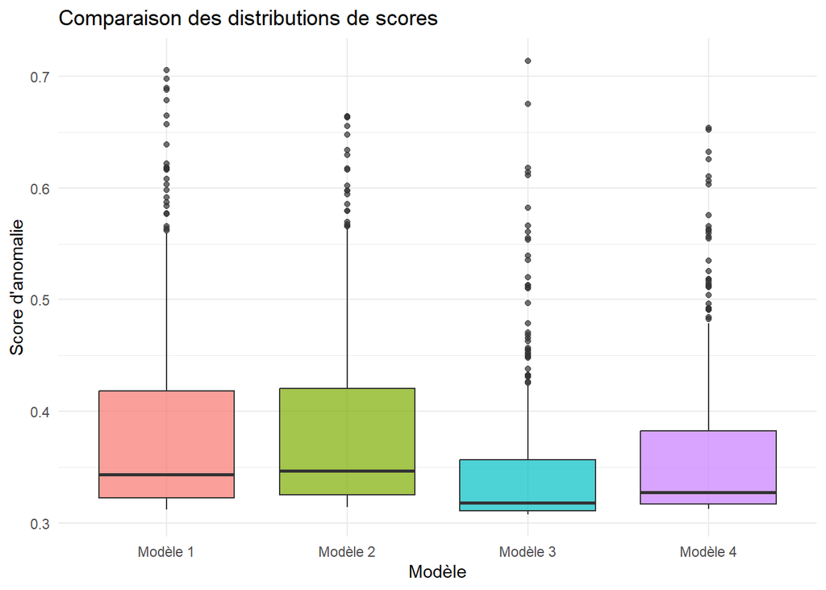

```r
# Boxplot comparatif
ggplot(all_scores_df, aes(x = model, y = score, fill = model)) +
  geom_boxplot(alpha = 0.7) +
  labs(title = "Comparaison des distributions de scores",
       x = "Modèle",
       y = "Score d'anomalie") +
  theme_minimal() +
  theme(legend.position = "none")
```

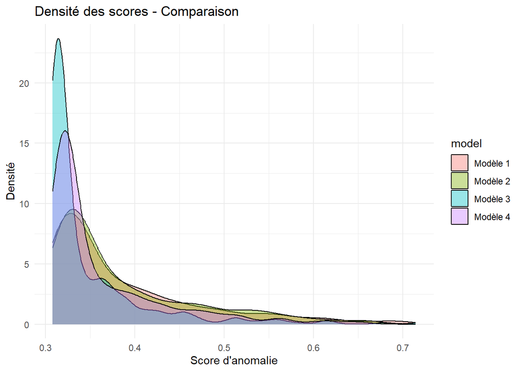

```r
# Density plot superposé
ggplot(all_scores_df, aes(x = score, fill = model)) +
  geom_density(alpha = 0.4) +
  labs(title = "Densité des scores - Comparaison",
       x = "Score d'anomalie",
       y = "Densité") +
  theme_minimal()
```

## Influence des hyperparamètres sur les modèles Isolation Forest

### Configuration des modèles testés

Nous testons 4 configurations différentes pour comprendre l’impact des hyperparamètres sur la détection d’anomalies :

```r
configs <- data.frame(
  model = c("Modèle 1", "Modèle 2", "Modèle 3", "Modèle 4"),
  ntrees = c(100, 500, 500, 250),
  sample_size = c(100, 100, 512, 256),
  ndim = c(1, 1, 3, 2)
)
knitr::kable(configs, caption = "Configuration des hyperparamètres testés")
```

Configuration des hyperparamètres testés

| model | ntrees | sample_size | ndim |
| --- | --- | --- | --- |
| Modèle 1 | 100 | 100 | 1 |
| Modèle 2 | 500 | 100 | 1 |
| Modèle 3 | 500 | 512 | 3 |
| Modèle 4 | 250 | 256 | 2 |

### Rôle des hyperparamètres

**1. `ntrees` (Nombre d’arbres)**

- **Principe** : Nombre d’arbres dans la forêt d’isolation
- **Impact** : Plus d’arbres = prédictions plus stables et robustes, mais temps de calcul accru
- **Recommandation** : Généralement entre 100 et 500 arbres

**2. `sample_size` (Taille d’échantillon)**

- **Principe** : Nombre d’observations utilisées pour construire chaque arbre
- **Impact** :
  - **Petit sample_size** (100-256) : Arbres plus petits, détection fine des anomalies, variance élevée
  - **Grand sample_size** (512+) : Arbres plus profonds, modèle plus stable mais peut manquer des anomalies subtiles
- **Recommandation** : Typiquement 256 observations pour un bon compromis

**3. `ndim` (Nombre de dimensions par split)**

- **Principe** : Nombre de features considérées simultanément pour chaque division de l’arbre
- **Impact** :
  - **ndim = 1** : Splits univariés (une feature à la fois), grande variance, sensible aux outliers individuels
  - **ndim > 1** : Splits multivariés, capture mieux les anomalies contextuelles complexes
- **Recommandation** : ndim = 1 pour détecter des anomalies simples, ndim = 2-3 pour des patterns multivariés

### Analyse comparative des résultats

```r
knitr::kable(comparison_results,
             digits = 4,
             caption = "Métriques de performance des 4 modèles")
```

Métriques de performance des 4 modèles

|  | model | ntrees | sample_size | ndim | variance | range | q95 | mean | sd |
| --- | --- | --- | --- | --- | --- | --- | --- | --- | --- |
| 95% | Modèle 1 | 100 | 100 | 1 | 0.0073 | 0.3936 | 0.5719 | 0.3857 | 0.0856 |
| 95%1 | Modèle 2 | 500 | 100 | 1 | 0.0066 | 0.3502 | 0.5606 | 0.3852 | 0.0814 |
| 95%2 | Modèle 3 | 500 | 512 | 3 | 0.0037 | 0.4064 | 0.4670 | 0.3454 | 0.0611 |
| 95%3 | Modèle 4 | 250 | 256 | 2 | 0.0046 | 0.3413 | 0.5126 | 0.3613 | 0.0678 |

#### Observations clés

**Modèle 1** (ntrees=100, sample_size=100, ndim=1) :

- **Variance la plus élevée** (0.0073) : attendu avec seulement 100 arbres et ndim=1
- **Q95 le plus haut** (0.5719) : discrimination plus agressive entre normal/anomalie
- **Interprétation** : Modèle le plus “sensible”, identifie plus facilement les anomalies mais risque de faux positifs

**Modèle 3** (ntrees=500, sample_size=512, ndim=3) :

- **Range maximal** (0.4064) : meilleure séparation globale des scores
- **Q95 plus bas** (0.467) : seuil d’anomalie plus conservateur
- **Interprétation** : Modèle plus stable et robuste, capture des anomalies multivariées complexes

**Modèle 2 vs Modèle 1** :

- Même configuration (ndim=1, sample_size=100) mais **5× plus d’arbres**
- Variance réduite grâce à l’effet d’ensemble (averaging)
- Q95 inférieur : prédictions plus conservatives

### Quel est le meilleur modèle ?

Sur la base de ces métriques exploratoires :

> **Le Modèle 1 semble le plus prometteur** pour notre tâche, avec son Q95 élevé et sa forte variance indiquant une bonne capacité de discrimination.

**Cependant**, cette conclusion préliminaire doit être **validée** en comparant les prédictions avec nos **234 outliers détectés par la méthode IQR** (lignes avec ≥3 features aberrantes). Le meilleur modèle sera celui qui :

1. Maximise le **F1-score** sur ces outliers de référence
2. Ne sur-détecte pas les lignes avec KPI1 = 0 comme anomalies systématiques
3. Capture des anomalies **multivariées complexes** plutôt que des seuils univariés

Cette validation fera l’objet de la section suivante.

```r
data_final$has_multiple_outliers <- 1:nrow(data_final) %in% outliers_detected

set.seed(123)
splitter <- data_final %>%
  rsample::initial_split(prop = 0.7, strata = has_multiple_outliers)

train <- rsample::training(splitter)
test  <- rsample::testing(splitter)

outliers_list_test <- lapply(test[, -ncol(test)], detect_outliers)  # Exclure la colonne has_multiple_outliers
lignes_outliers_test <- unique(unlist(outliers_list_test))

outliers_detected_test <- c()
for(ligne in lignes_outliers_test) {
  features_pb <- names(outliers_list_test)[sapply(outliers_list_test, function(x) ligne %in% x)]
  if(length(features_pb) >= 3) {
    outliers_detected_test <- c(outliers_detected_test, ligne)
  }
}

cat("Outliers détectés dans test (>= 3):", length(outliers_detected_test), "\n")
```

```
## Outliers détectés dans test (>= 3): 73
```

```r
params_grid <- expand.grid(
  ntrees = c(100, 250, 500),
  sample_size = c(128, 256, 512),
  ndim = c(1, 2, 3)
)

compare_outliers <- function(predicted, detected) {
  communs <- intersect(predicted, detected)

  # Taux de détection
  taux <- length(communs) / length(detected) * 100

  # F1-score
  precision <- length(communs) / length(predicted)
  recall <- length(communs) / length(detected)
  f1 <- 2 * (precision * recall) / (precision + recall)

  return(list(communs = length(communs), taux = taux, f1 = f1))
}

results <- data.frame()

for(i in 1:nrow(params_grid)) {
  cat("Test modèle", i, "/", nrow(params_grid), "\n")

  model_temp <- isolation.forest(train[, -ncol(train)],  # Exclure has_multiple_outliers
                                 ntrees = params_grid$ntrees[i],
                                 sample_size = params_grid$sample_size[i],
                                 ndim = params_grid$ndim[i])

  scores_test <- predict(model_temp, test[, -ncol(test)])
  seuil <- quantile(scores_test, 0.95)
  lignes_predites <- which(scores_test > seuil)

  # Comparaison
  comp_result <- compare_outliers(lignes_predites, outliers_detected_test)

  results <- rbind(results, data.frame(
    ntrees = params_grid$ntrees[i],
    sample_size = params_grid$sample_size[i],
    ndim = params_grid$ndim[i],
    communs = comp_result$communs,
    taux_detection = comp_result$taux,
    f1_score = comp_result$f1
  ))
}
```

```
## Test modèle 1 / 27
## Test modèle 2 / 27
## Test modèle 3 / 27
## Test modèle 4 / 27
## Test modèle 5 / 27
## Test modèle 6 / 27
## Test modèle 7 / 27
## Test modèle 8 / 27
## Test modèle 9 / 27
## Test modèle 10 / 27
## Test modèle 11 / 27
## Test modèle 12 / 27
## Test modèle 13 / 27
## Test modèle 14 / 27
## Test modèle 15 / 27
## Test modèle 16 / 27
## Test modèle 17 / 27
## Test modèle 18 / 27
## Test modèle 19 / 27
## Test modèle 20 / 27
## Test modèle 21 / 27
## Test modèle 22 / 27
## Test modèle 23 / 27
## Test modèle 24 / 27
## Test modèle 25 / 27
## Test modèle 26 / 27
## Test modèle 27 / 27
```

```r
# 6. CLASSEMENT DES MODÈLES
results <- results[order(-results$f1_score), ]
cat("\n### Top 5 modèles (selon F1-score)\n")
```

```
##
## ### Top 5 modèles (selon F1-score)
```

```r
print(head(results, 5))
```

```
##    ntrees sample_size ndim communs taux_detection  f1_score
## 2     250         128    1      21       28.76712 0.4468085
## 3     500         128    1      21       28.76712 0.4468085
## 10    100         128    2      21       28.76712 0.4468085
## 1     100         128    1      19       26.02740 0.4042553
## 4     100         256    1      19       26.02740 0.4042553
```

```r
print(tail(results, 5))
```

```
##    ntrees sample_size ndim communs taux_detection  f1_score
## 21    500         128    3      17       23.28767 0.3617021
## 22    100         256    3      17       23.28767 0.3617021
## 25    100         512    3      17       23.28767 0.3617021
## 26    250         512    3      17       23.28767 0.3617021
## 27    500         512    3      17       23.28767 0.3617021
```

différence de 4 outliers commun entre les modèles testé.

```r
# Récupérer les 3 modèles à analyser
best_model_1 <- results[1, ]
best_model_2 <- results[2, ]
worst_model <- results[nrow(results), ]

models_to_analyze <- list(
  list(params = best_model_1, name = "Meilleur modèle"),
  list(params = best_model_2, name = "2ème meilleur modèle"),
  list(params = worst_model, name = "Pire modèle")
)

# Fonction pour analyser un modèle
analyze_model <- function(params, model_name) {
  cat("\n### ", model_name, "\n")
  cat("Paramètres: ntrees =", params$ntrees, ", sample_size =", params$sample_size,
      ", ndim =", params$ndim, "\n")
  cat("F1-score:", round(params$f1_score, 3), "| Taux détection:",
      round(params$taux_detection, 2), "%\n\n")

  # Entraîner le modèle
  model <- isolation.forest(train[, -ncol(train)],
                           ntrees = params$ntrees,
                           sample_size = params$sample_size,
                           ndim = params$ndim)

  scores <- predict(model, test[, -ncol(test)])
  test$anomaly_score <- scores

  # Top 5 scores les plus hauts
  top5_high <- test[order(-test$anomaly_score), ][1:5, ]
  cat("#### Top 5 scores d'anomalies les plus élevés\n")
  print(top5_high[, c("anomaly_score")])
  cat("\n")

  # Top 5 scores les plus bas
  top5_low <- test[order(test$anomaly_score), ][1:5, ]
  cat("#### Top 5 scores d'anomalies les plus bas\n")
  print(top5_low[, c("anomaly_score")])
  cat("\n")

  # Statistiques des scores
  cat("#### Statistiques des scores\n")
  cat("- Moyenne:", round(mean(scores), 4), "\n")
  cat("- Médiane:", round(median(scores), 4), "\n")
  cat("- Écart-type:", round(sd(scores), 4), "\n")
  cat("- Min:", round(min(scores), 4), "| Max:", round(max(scores), 4), "\n")
  cat("- Range:", round(max(scores) - min(scores), 4), "\n\n")

  # Vérifier si les top anomalies sont dans outliers_detected
  indices_high <- as.numeric(rownames(top5_high))
  in_outliers_high <- sum(indices_high %in% outliers_detected_test)
  cat("Parmi le top 5, ", in_outliers_high, " sont des outliers détectés (IQR)\n\n")

  return(scores)
}

# Analyser les 3 modèles
scores_best1 <- analyze_model(best_model_1, "Meilleur modèle")
```

```
##
## ###  Meilleur modèle
## Paramètres: ntrees = 250 , sample_size = 128 , ndim = 1
## F1-score: 0.447 | Taux détection: 28.77 %
##
## #### Top 5 scores d'anomalies les plus élevés
## [1] 0.7426383 0.7315695 0.7087021 0.6702775 0.6610300
##
## #### Top 5 scores d'anomalies les plus bas
## [1] 0.3190678 0.3190776 0.3190776 0.3190776 0.3190776
##
## #### Statistiques des scores
## - Moyenne: 0.3834
## - Médiane: 0.3479
## - Écart-type: 0.0811
## - Min: 0.3191 | Max: 0.7426
## - Range: 0.4236
##
## Parmi le top 5,  5  sont des outliers détectés (IQR)
```

```r
scores_best2 <- analyze_model(best_model_2, "2ème meilleur modèle")
```

```
##
## ###  2ème meilleur modèle
## Paramètres: ntrees = 500 , sample_size = 128 , ndim = 1
## F1-score: 0.447 | Taux détection: 28.77 %
##
## #### Top 5 scores d'anomalies les plus élevés
## [1] 0.7344542 0.7317532 0.6995803 0.6611023 0.6549343
##
## #### Top 5 scores d'anomalies les plus bas
## [1] 0.3187112 0.3187112 0.3187112 0.3187112 0.3187112
##
## #### Statistiques des scores
## - Moyenne: 0.3838
## - Médiane: 0.3473
## - Écart-type: 0.0803
## - Min: 0.3187 | Max: 0.7345
## - Range: 0.4157
##
## Parmi le top 5,  5  sont des outliers détectés (IQR)
```

```r
scores_worst <- analyze_model(worst_model, "Pire modèle")
```

```
##
## ###  Pire modèle
## Paramètres: ntrees = 500 , sample_size = 512 , ndim = 3
## F1-score: 0.362 | Taux détection: 23.29 %
##
## #### Top 5 scores d'anomalies les plus élevés
## [1] 0.7184615 0.6812504 0.6529226 0.6469607 0.6422075
##
## #### Top 5 scores d'anomalies les plus bas
## [1] 0.3094624 0.3094624 0.3094624 0.3094624 0.3094674
##
## #### Statistiques des scores
## - Moyenne: 0.3511
## - Médiane: 0.32
## - Écart-type: 0.0681
## - Min: 0.3095 | Max: 0.7185
## - Range: 0.409
##
## Parmi le top 5,  4  sont des outliers détectés (IQR)
```

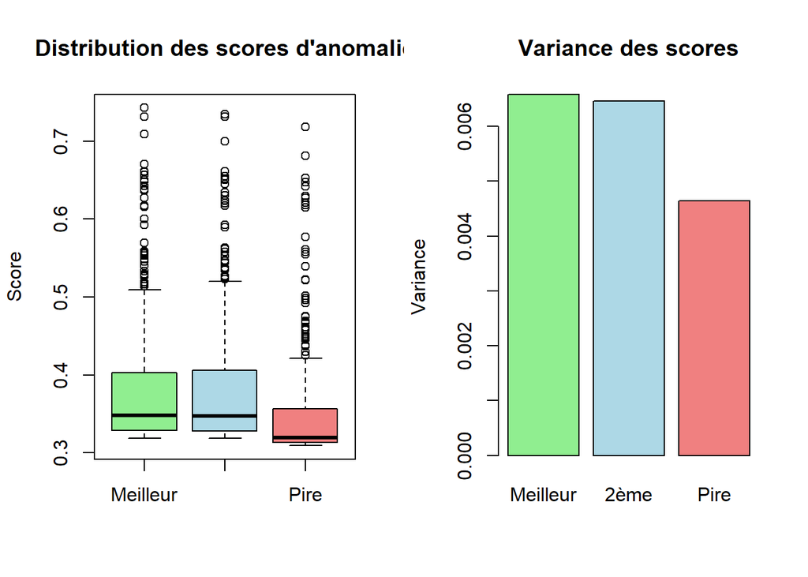

```r
# Comparaison graphique (2 plots seulement)
par(mfrow = c(1, 2))

# Plot 1: Distribution des scores
boxplot(list(Meilleur = scores_best1,
             Deuxieme = scores_best2,
             Pire = scores_worst),
        col = c("lightgreen", "lightblue", "lightcoral"),
        main = "Distribution des scores d'anomalie",
        ylab = "Score")

# Plot 2: Variance des scores
variances <- c(var(scores_best1), var(scores_best2), var(scores_worst))
barplot(variances,
        names.arg = c("Meilleur", "2ème", "Pire"),
        col = c("lightgreen", "lightblue", "lightcoral"),
        main = "Variance des scores",
        ylab = "Variance")
```

```r
par(mfrow = c(1, 1))

# Analyse comparative finale
cat("\n### Analyse comparative\n")
```

```
##
## ### Analyse comparative
```

```r
cat("**Variance des scores:**\n")
```

```
## **Variance des scores:**
```

```r
cat("- Meilleur modèle:", round(var(scores_best1), 6), "\n")
```

```
## - Meilleur modèle: 0.006581
```

```r
cat("- 2ème modèle:", round(var(scores_best2), 6), "\n")
```

```
## - 2ème modèle: 0.006455
```

```r
cat("- Pire modèle:", round(var(scores_worst), 6), "\n\n")
```

```
## - Pire modèle: 0.004641
```

```r
cat("**Interprétation:**\n")
```

```
## **Interprétation:**
```

```r
cat("Une variance plus élevée indique une meilleure séparation entre anomalies et données normales.\n")
```

```
## Une variance plus élevée indique une meilleure séparation entre anomalies et données normales.
```

```r
cat("Les meilleurs modèles devraient avoir un range plus large et mieux identifier les outliers IQR.\n")
```

```
## Les meilleurs modèles devraient avoir un range plus large et mieux identifier les outliers IQR.
```